# The Effects of Marijuana Legalization on Crime and Other Drug Usage in Seattle

Benjamin Gaiser and Jeremy Russell

16 December 2016

## Why Weed?

Individuals on either side of the marijuana legalization divide often make spectacular claims regarding the expected effects of legalization. Some fear that legalization is undesirable for moral reasons, while others are concerned that legalization will lead to further abuses of illicit substances. Yet changing attitudes toward the use of cannabis and the previous stigma surrounding it undergird a larger shift in the legal and regulatory landscape concerning the drug’s potential medicinal uses, and its production, distribution, and taxation. As with many policy issues, money plays an obvious role. With moral arguments falling behind more liberal views on drugs and their use, the potential for states to raise millions in tax revenues often takes preeminence over other concerns. That is not to say that public health and safety does not matter to the discussion; some legalization initiatives funnel a portion of marijuana tax revenue into research on the health effects of the drug. For the most part, in purely economic terms, the costs associated with policing neighborhoods and jailing those convicted of possession or distribution seem to far outweigh the benefits of over-policing and criminalization.

Perhaps also because more individuals know someone who has used marijuana recreationally or has been prescribed medical marijuana, more people disagree with harsh penalties that have been in place for several decades now in the United States. This again hints at changing public opinions on the drug, and says less about the actual effects that legalization has had in the states that have chosen to regulate the production and sale of recreational cannabis.

In our research, we explore marijuana legalization by aiming to address policy implications rather than normative arguments either for or against it. We hope that by doing so we contribute to the growing research on the topic, as it continues to play a prominent role in current debates in the U.S. and abroad.

## Everything Data: Where’d We Get It and How?

Our project used three data sets: i) cannabis data on Washington State, ii) crime data on Seattle, WA, and iii) socio-economic data on Seattle, WA. As the policy field of cannabis legalization is a nascent field of study, reliable data were few and far between.

Our project began with the ‘Washington Initiative 502’, the initiative that brought about the legalization of cannabis, and published data about producers and retailers in the state. We scraped the data using the rvest package. And since there were difficulties with the site being written in Java, we needed the ‘phantomjs’ file to use the RSelenium package to make things a bit more manageable.

As the “.exe”-file does not work on Mac products and Apple operating systems, and because scraping is time-consuming, we made a “.txt”-file called “ProdProc” for all producers and processors and one called “Retailer” for retailers, allowing for as much reproducibility as possible. The data lists the names and locations of producers and processors in the state and of retailers including year-to-date sales and tax revenue.

The second set of data concerns crime. We scraped the data for Seattle with the jsonlite package and formatted it into R-readable format with the gdata package. Since the initial data set was large (>80 MB), we made it a zipped-file called “CrimeSeattle.gz”. For the analysis, we cleaned the data so to only contain information about the longitude/latitude, the type of crime and the time it has occurred. For types of crime, we aggregated individual types into seven broad categories: i) alcohol-related crime (includes Liquor offenses and DUI offenses), ii) burglary/theft, iii) marijuana-related crime, iv) narcotics-related crime, v) other-drug related crimes, vi) property crime, and vii) violent crime (includes armed robberies, assaults, drive-by shootings, strong armed robbery and homicides).

The third set of data comes from the U.S. Census data and provides us with socio-economic factors for each district. Our code to obtain these data follows [the concept of the blog post by zevross](http://zevross.com/blog/2015/10/14/manipulating-and-mapping-us-census-data-in-r-using-the-acs-tigris-and-leaflet-packages-3/). One limitation is that we, however, only have this data annually and only for 2014. The variables included for this analysis are the share of poverty for each district, the average age level, the prevalence of minority races, as well as the level of education. While these are classic socio-economic factors, the lack of variation means that they will only be useful for the regular OLS regression as well as for the propensity score matching, which means that this set of data will be of limited value overall.

To merge all three data sets, we needed to ensure that we had geospatial data in all of them. Only for the first data set did we not already have longitude and latitude data. To obtain these, we scraped the street locations for all available retailers from [kushtourism.com](http://kushtourism.com/washington-recreational-marijuana-retail-map-and-directory/#Seattle). With this information, we were able to use a simple Google API query in combination with the RJSONIO package to determine latitude and longitude for each observation. This left us with 15 individual retailers for Seattle for which we have data. For the merger of all three data sets, we calculated the centroid of each district of the U.S. Census Data and then calculated the minimum distance of crime incidents and retailers using the fields package. The final data set is called “SeattleCrimeAnalysis.gz”. As we are not looking at the individual perpetrator but at the crime incident of a district, we feel that this is an adequate way of merging the data set.

## Our Findings

While the 502data is well documented, the retailers’ names aren’t given. As a result, we used the names for producers/processors to get their numbers, and used the URL extensions to identify how many retailers there were.

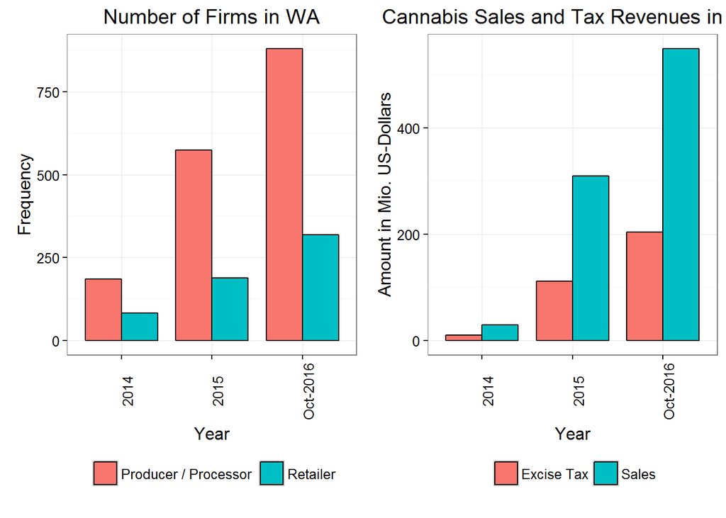

As we can see from Figure 1, industry is booming in Washington with both the numbers of actors and the sales/tax revenues already higher in October 2016 than in all of 2015. The numbers are quite staggering:

1. Number of Producers and Processors: The number increased by 210% YoY in 2015 from 185 to 574 and by another 53% in the ten months leading up to October 2016 to 881.
2. Number of Retailers: The number increased by 130% YoY in 2015 from 82 to 189 and by another 69% in the ten months leading up to October 2016 to 319.
3. Increase of revenues in sales: The number increased by 960% YoY in 2015 from $29.21 Mill to $309.86 Mill and by another 77% in the ten months leading up to October 2016 to $549.93 Mill.
4. Increase of tax revenues: The number increased by 1040% YoY in 2015 from $9.74 Mill to $110.97 Mill and by another 83% in the ten months leading up to October 2016 to $203.47 Mill.

It’s a fast growing industry, and buyers are showing more interest. In relation to Washington State’s GDP it is, however, still relatively small with a share of 0.12 % of a GDP of [$445.4 Bill](https://www.bea.gov/regional/bearfacts/pdf.cfm?fips=53000&areatype=STATE&geotype=3). Unfortunately, we don’t have data on the quantities that have been sold or reliable data on the price development of the good. In either of these scenarios we could have otherwise also analysed the usage.

Like most large cities in the U.S., crime is an issue in Seattle as well. If we look at Figure 2, we can see the distribution of our different crime categories for October 2016. We can clearly see that crime is concentrated in central Seattle, and that there is less crime around the red dots that represent the existence of a dispensary. The stark concentration of crime follows the experience of other big cities: take Boston as an example where “fewer than 5 percent of [its] street corners and block faces generated 74 percent of fatal and non-fatal shootings between 1980 and 2008”.

[figure not shown]

## Inferential Stats

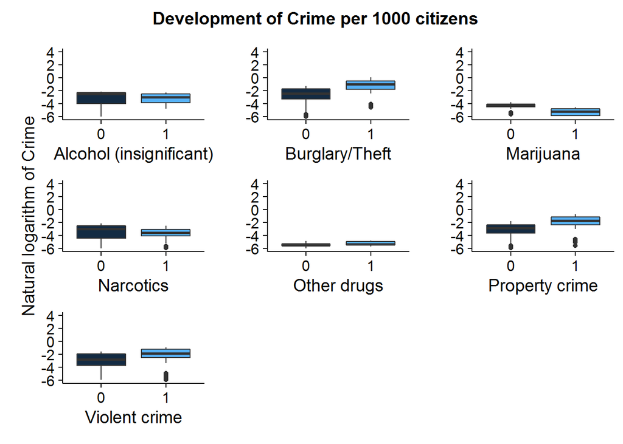

## Discussion

Consistent with our findings, we conclude that the establishment of a marijuana dispensary is positively related with an increase in the crime rate for that district. Perhaps we see this increase because our data spans a shorter time period than the data used in the Cato publication; however, were we to use longitudinal data, for instance, we suspect our outcomes to be consistent with those in the Cato report. One limitation to our research outcomes depends on our chosen variables; had we looked at unemployment as a socio-economic factor affecting crime rates, we might have been able to capture a more complete picture since this data is available month-to-month. In addition to Poverty Rate, Age, and Diversity, we could have used a housing price index similar to the S&P Case-Shiller Home Price Index, which is the market standard in data on U.S. residential real estate prices. Another issue worth mentioning is that burglary/theft, and property and violent crimes might show an upward trend because of other omitted variables; another explanation is that the rises in crime correlate to previous drug sellers being out of a job. This does not seem to be the case, though, given the fact that the trend in the data is so late. Perhaps another variable could have been political leaning, liberal or conservative, but the data we accessed did not specify any such variable. Given our emphasis on districts and geo-spatial data, another concern of ours was the issue of dispensaries “self-selecting” to locate in more suitable districts rather than in those where crime is expected to be higher.

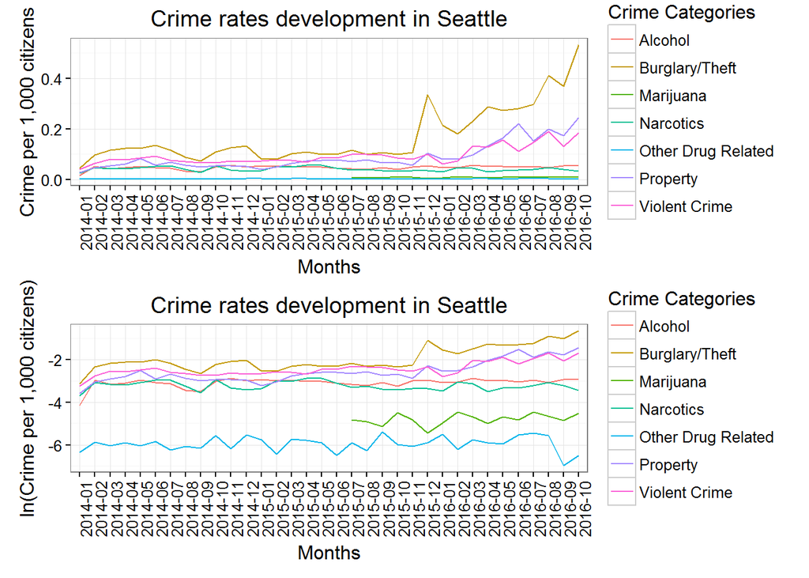